# INDE546_HW7

Michael Shieh

2/25/2020

```r
setwd("~/Documents/UW/2020Winter/INDE546_InferentialDataAnalysis/HW/HW7")
survey <- read.csv("Class_Survey_W20.csv", header = TRUE)
```

# Exercise 1

#### In this model, I want to see what could be the significant factors for affecting the frequency of the participants taking an Uber/Lyft. The data for this variable is from question 11 of the survey.

#### First, I replaced the NA value with 0, and I noticed there was a 100 in the responses, which is very unlikely, so I removed it as an outlier to make sure it wouldn’t affect the model.

```r
survey <- survey %>%
  rename(UberRide = In.the.past.7.days..how.many.rides.did.you.hail.using.an.Uber.Lyft.app..) %>%
  mutate(UberRide = replace_na(UberRide, 0)) %>%
  filter(UberRide < 100)
```

#### Next, I plot the data to see how it is distributed.

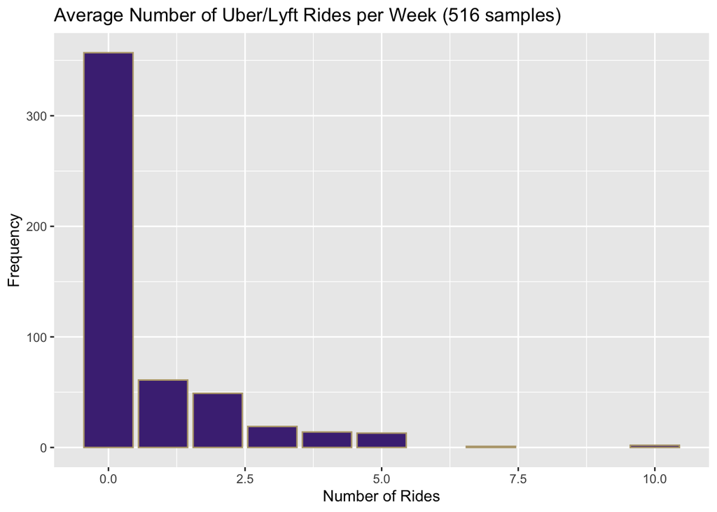

```r
ggplot(data = survey, aes(x = UberRide)) +
  geom_bar(fill = "#4B2E83", colour = "#b7a57a") +
  labs(title = 'Average Number of Uber/Lyft Rides per Week (516 samples)', y = "Frequency", x = "Number of Rides")
```

#### As the histogram showed, the data is strongly skewed toward 0.

```r
table <- cbind("Mean" = mean(survey$UberRide), "Var" = var(survey$UberRide), "Min" = min(survey$UberRide), "Max" = max(survey$UberRide))
rownames(table) = c("UberRide")
print(xtable::xtable(table), type = "html", html.table.attributes = "border=3")
```

|  | Mean | Var | Min | Max |
| --- | --- | --- | --- | --- |
| UberRide | 0.71 | 1.88 | 0.00 | 10.00 |

#### Since the variance of the variable is larger the mean, due to overdispersion, I chose to use negative binomial model to analyze the model.

# Exercise 2

#### The first independent variable I chose was whether the particiapnts are willing to share an Uber/Lyft with strangers. This variable is from question 13 of the survey. I chose this variable because I think that if you are not willing to share ride with strangers, you may not like sitting in stranger’s cars. Therefore, less likely to take an Uber/Lyft.

```r
survey <- survey %>%
  rename(ShareUber = How.often.do.you...share.an.Uber.Lyft.ride.with.someone.you.did.not.know.) %>%
  mutate(ShareUber = ifelse(ShareUber %in% c("Always", "Often", "Sometimes", "Rarely"), "Yes", "No"))
```

```r
survey1 <- survey %>% filter(ShareUber == "Yes")
survey2 <- survey %>% filter(ShareUber == "No")


obs <- c(nrow(survey1), nrow(survey2), nrow(survey))
mean <- c(mean(survey1$UberRide), mean(survey2$UberRide), mean(survey$UberRide))
var <- c(var(survey1$UberRide), var(survey2$UberRide), var(survey$UberRide))
min <- c(min(survey1$UberRide), min(survey2$UberRide), min(survey$UberRide))
max <- c(max(survey1$UberRide), max(survey2$UberRide), max(survey$UberRide))

table2 <- cbind("Obs" = obs, "Mean" = mean, "Var." = var, "Min" = min, "Max" = max)
rownames(table2) <- c("Yes", "No", "Total")

print(xtable::xtable(table2), type = "html", html.table.attributes = "border=3")
```

|  | Obs | Mean | Var. | Min | Max |
| --- | --- | --- | --- | --- | --- |
| Yes | 184.00 | 1.45 | 2.53 | 0.00 | 10.00 |
| No | 332.00 | 0.30 | 1.05 | 0.00 | 10.00 |
| Total | 516.00 | 0.71 | 1.88 | 0.00 | 10.00 |

#### From the table above, it seems if the particapants are willing to share their Uber/Lyft, they are more likely to take more Uber/Lyft on average. Therefore, this is definitely a variable worth exploring in this model.

#### The second independent variable was the commute time of the participants. I chose this variable because that I’m curious to see what type of participants are more likely to take an Uber/Lyft. Is it the ones who live farther, or otherwise.

```r
survey <- survey %>%
  rename(CommuteTime = On.average..how.many.minutes.does.it.take.you.to.get.to.the.U..Washington.from.your.home.) %>%
  filter(CommuteTime >= 0)
```

#### I draw a box plot to describe this variable to see if there’s any initial trends I can tell.

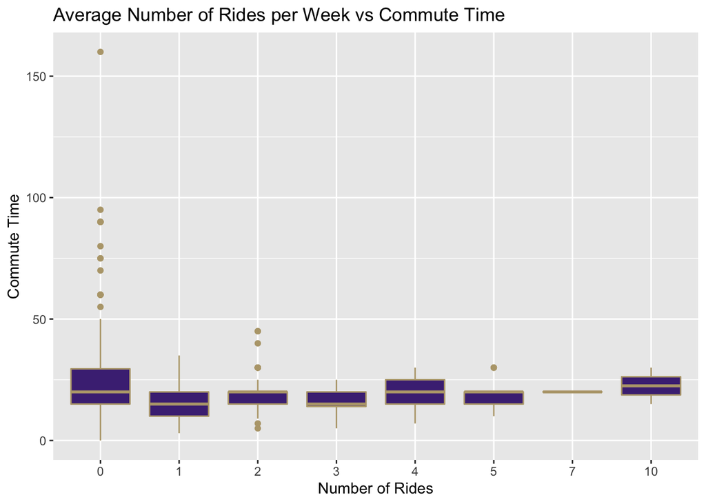

```r
survey2 <- survey
survey2$UberRide <- factor(survey2$UberRide, levels = c(0, 1, 2, 3, 4, 5, 6, 7, 8, 9, 10), labels = c("0", "1", "2", "3", "4", "5", "6", "7", "8", "9", "10"))
ggplot(data = survey2, aes(y = CommuteTime, x = UberRide)) +
  geom_boxplot(fill = "#4B2E83", color = "#b7a57a") +
  labs(title = "Average Number of Rides per Week vs Commute Time", x = "Number of Rides", y = "Commute Time")
```

#### From the boxplot, it seemed that people with longer commute time (30+ minutes) tend to not use Uber/Lyft.

#### The third independent variable was the primary means of transportation of the particiants. This variable is from question 1 of the survey. I chose this variable because I’m interested to see if there is a group of commuters wouldutilize Uber/Lyft more.

```r
survey <- survey %>%
  rename(TransMode = What.is.your.primary.means.of.transportation.to.and.from.the.U..Washington.) %>%
  mutate(TransMode = case_when(TransMode == 'Bus' ~ 1, TransMode == 'Drive' ~ 2, TransMode == 'Walk' ~ 3, TransMode == 'Light rail' ~ 4)) %>%
  mutate(TransMode = replace_na(TransMode, 5))

survey$TransMode <- factor(survey$TransMode, levels = c(1, 2, 3, 4, 5), labels = c("Bus", "Drive", "Walk", "Light rail", "Others"))
survey$TransMode <- relevel(survey$TransMode, ref = "Others")
```

#### Next, I used a table to summarize this variable and its relationship to the dependent variable.

```r
survey1 <- survey %>% filter(TransMode == "Bus")
survey2 <- survey %>% filter(TransMode == "Drive")
survey3 <- survey %>% filter(TransMode == "Walk")
survey4 <- survey %>% filter(TransMode == "Light rail")
survey5 <- survey %>% filter(TransMode == "Others")

obs <- c(nrow(survey1), nrow(survey2), nrow(survey3), nrow(survey4), nrow(survey5), nrow(survey))
mean <- c(mean(survey1$UberRide), mean(survey2$UberRide), mean(survey3$UberRide), mean(survey4$UberRide), mean(survey5$UberRide), mean(survey$UberRide))
var <- c(var(survey1$UberRide), var(survey2$UberRide), var(survey3$UberRide), var(survey4$UberRide), var(survey5$UberRide), var(survey$UberRide))
min <- c(min(survey1$UberRide), min(survey2$UberRide), min(survey3$UberRide), min(survey4$UberRide), min(survey5$UberRide), min(survey$UberRide))
max <- c(max(survey1$UberRide), max(survey2$UberRide), max(survey3$UberRide), max(survey4$UberRide), max(survey5$UberRide), max(survey$UberRide))

table3 <- cbind("Obs" = obs, "Mean" = mean, "Var." = var, "Min" = min, "Max" = max)
rownames(table3) <- c("Bus", "Drive", "Walk", "Light rail", "Others", "Total")


print(xtable::xtable(table3), type = "html", html.table.attributes = "border=3")
```

|  | Obs | Mean | Var. | Min | Max |
| --- | --- | --- | --- | --- | --- |
| Bus | 225.00 | 0.71 | 1.86 | 0.00 | 10.00 |
| Drive | 41.00 | 0.71 | 2.41 | 0.00 | 7.00 |
| Walk | 203.00 | 0.75 | 1.98 | 0.00 | 10.00 |
| Light rail | 14.00 | 0.50 | 0.73 | 0.00 | 2.00 |
| Others | 26.00 | 0.62 | 1.69 | 0.00 | 5.00 |
| Total | 509.00 | 0.72 | 1.90 | 0.00 | 10.00 |

#### The variances between each group are consistently larger than the mean, but there’s no indications that the average number of Uber/Lyft rides per week between groups differ drastically. Next, I draw a plot to see how did the observations spreaded between each average number of rides.

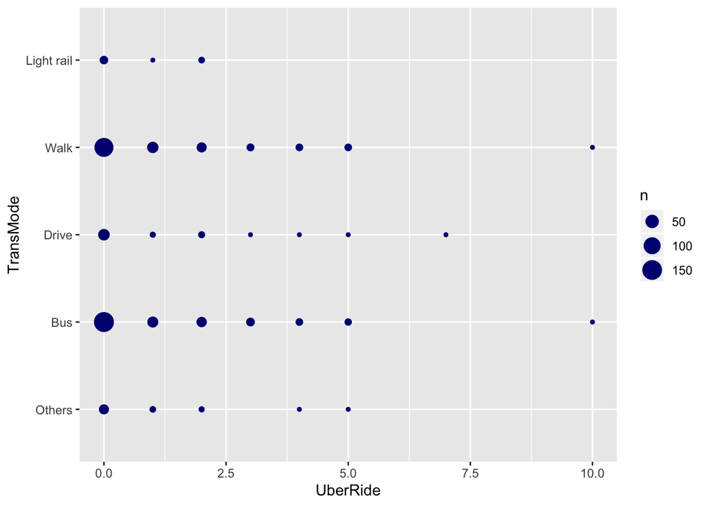

```r
ggplot(survey, aes(x = UberRide, y = TransMode))+
  geom_count(color = "Navy Blue")
```

#### From the plot above, it seems that some of the commuters who utilize buses or walk primarily take Uber/Lyft more often. However, no relationships can be observed directly.

# Exercise 3 and 4

#### First, I inputed all independent variables into the model.

```r
model_nb <- glm.nb(UberRide ~ CommuteTime + TransMode + ShareUber, data = survey)
#summary(model_nb)

table4 <- coef(summary(model_nb))
table4 <- round(cbind(table4, "Estimate" = exp(coef(model_nb)), exp(confint(model_nb))),3)
rownames(table4) <- c("Intercept", "Commute Time", "Take Bus", "Drive", "Walk", "Light Rail", "Willing to share Uber/Lyft")
print(xtable::xtable(table4), type = "html", html.table.attributes = "border = 2")
```

|  | Estimate | Std. Error | z value | Pr(>\|z\|) | Estimate | 2.5 % | 97.5 % |
| --- | --- | --- | --- | --- | --- | --- | --- |
| Intercept | -1.05 | 0.45 | -2.33 | 0.02 | 0.35 | 0.15 | 0.85 |
| Commute Time | -0.02 | 0.01 | -2.57 | 0.01 | 0.98 | 0.96 | 0.99 |
| Take Bus | 0.42 | 0.43 | 0.99 | 0.32 | 1.53 | 0.67 | 3.44 |
| Drive | 0.39 | 0.52 | 0.75 | 0.45 | 1.47 | 0.56 | 3.89 |
| Walk | 0.15 | 0.43 | 0.34 | 0.73 | 1.16 | 0.51 | 2.61 |
| Light Rail | 0.10 | 0.71 | 0.14 | 0.89 | 1.10 | 0.28 | 4.35 |
| Willing to share Uber/Lyft | 1.62 | 0.17 | 9.55 | 0.00 | 5.04 | 3.63 | 7.05 |

#### From the result above, I decided to remove the insignificant variable “TransMode”, and re-run the model.

```r
model_nb2 <- glm.nb(UberRide ~ CommuteTime + ShareUber, data = survey)
#summary(model_nb)

table5 <- coef(summary(model_nb2))
table5 <- round(cbind(table5, "Estimate" = exp(coef(model_nb2)), exp(confint(model_nb2))),3)
rownames(table5) <- c("Intercept", "Commute Time", "Willing to share Uber/Lyft")
print(xtable::xtable(table5), type = "html", html.table.attributes = "border = 2")
```

|  | Estimate | Std. Error | z value | Pr(>\|z\|) | Estimate | 2.5 % | 97.5 % |
| --- | --- | --- | --- | --- | --- | --- | --- |
| Intercept | -0.81 | 0.20 | -3.97 | 0.00 | 0.45 | 0.30 | 0.67 |
| Commute Time | -0.02 | 0.01 | -2.46 | 0.01 | 0.98 | 0.96 | 1.00 |
| Willing to share Uber/Lyft | 1.58 | 0.17 | 9.39 | 0.00 | 4.86 | 3.51 | 6.77 |

#### The final model shows that both of the remaining variables are significant. It showed that for each one-unit increases in commute time, the expected log count of average number of Uber/Lyft rides decreases by 0.02. This result match the original observation that participants who have longer commute time tend to take less Uber/Lyft ride. Moreover, The expected log count is 1.58 higher for the participants who are willing to share an Uber/Lyft ride comparing to those who aren’t. This also match what I saw earlier that average number of Uber/Lyft rides is higher for the willing-to-share case. The confidence interval also confirmed the result above.

```r
ini_conv <- c(model_nb$null.deviance, model_nb2$null.deviance)
fin_conv <- c(model_nb$deviance, model_nb2$deviance)
aic <- c(model_nb$aic, model_nb2$aic)
df <- c(model_nb$df.residual, model_nb2$df.residual)

table6 <- cbind("Initial Convergence" = ini_conv, "Final Convergence" = fin_conv, "AIC" = aic, "df" = df)
rownames(table6) <- c("Model w/ TransMode", "Model w/o TransMode")
print(xtable::xtable(table6), type = "html", html.table.attribute = "border = 2")
```

|  | Initial Convergence | Final Convergence | AIC | df |
| --- | --- | --- | --- | --- |
| Model w/ TransMode | 492.01 | 382.37 | 1062.35 | 502.00 |
| Model w/o TransMode | 488.60 | 382.75 | 1057.27 | 506.00 |

#### Lastly, I wanted to compare this model with others to make sure I select the better approach, so I ran the Poisson model.

```r
model_pois <- glm(UberRide ~ CommuteTime + ShareUber, data = survey, family = poisson)

table7 <- cbind("Negative Binomial" = c(model_nb2$aic, logLik(model_nb2)), "Poisson" = c(model_pois$aic, logLik(model_pois)))
rownames(table7) <- c("AIC", "LogLikelihood")

print(xtable::xtable(table7), type = "html", html.table.attribute = "border = 1")
```

|  | Negative Binomial | Poisson |
| --- | --- | --- |
| AIC | 1057.27 | 1187.76 |
| LogLikelihood | -524.63 | -590.88 |

```r
table8 <- cbind("Ratio of Log Likelihoods" = 2*(logLik(model_nb2) - logLik(model_pois)),
                "Test for Significance" = pchisq(2*(logLik(model_nb2) - logLik(model_pois)), df = 1, lower.tail = FALSE))

print(xtable::xtable(table8), type = "html", html.table.attribute = "border = 1")
```

|  | Ratio of Log Likelihoods | Test for Significance |
| --- | --- | --- |
| 1 | 132.50 | 0.00 |